# Spatial Models HW

Hunt Jones

2/22/2022

## Spatial Modeling Assignment

```r
library(vegan)
data(BCI)
## UTM Coordinates (in metres)
BCI_xy = data.frame(x = rep(seq(625754, 626654, by=100), each=5),
                    y = rep(seq(1011569,  1011969, by=100), len=50))
```

1. Examine if there is evidence of spatial dependence in a rare and a common species in the BCI tree dataset

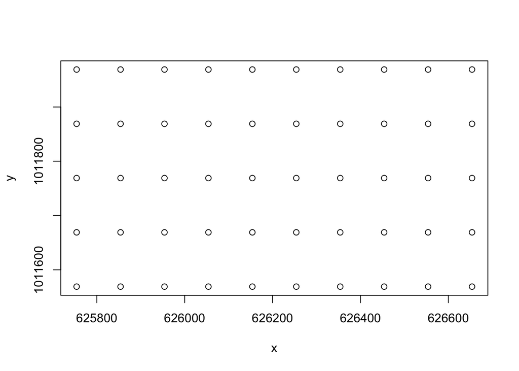

```r
plot(BCI_xy)
```

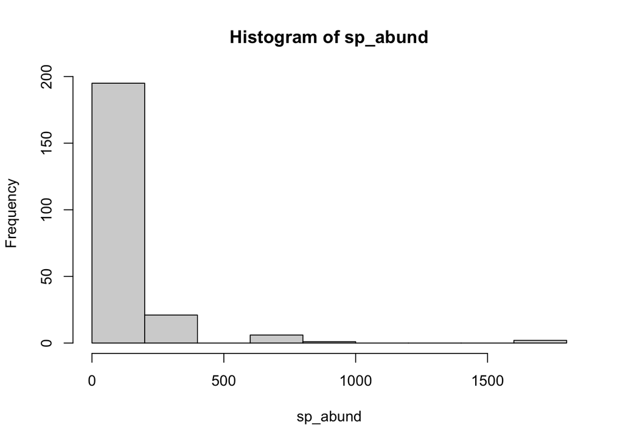

```r
sp_abund <- colSums(BCI)
hist(sp_abund)
```

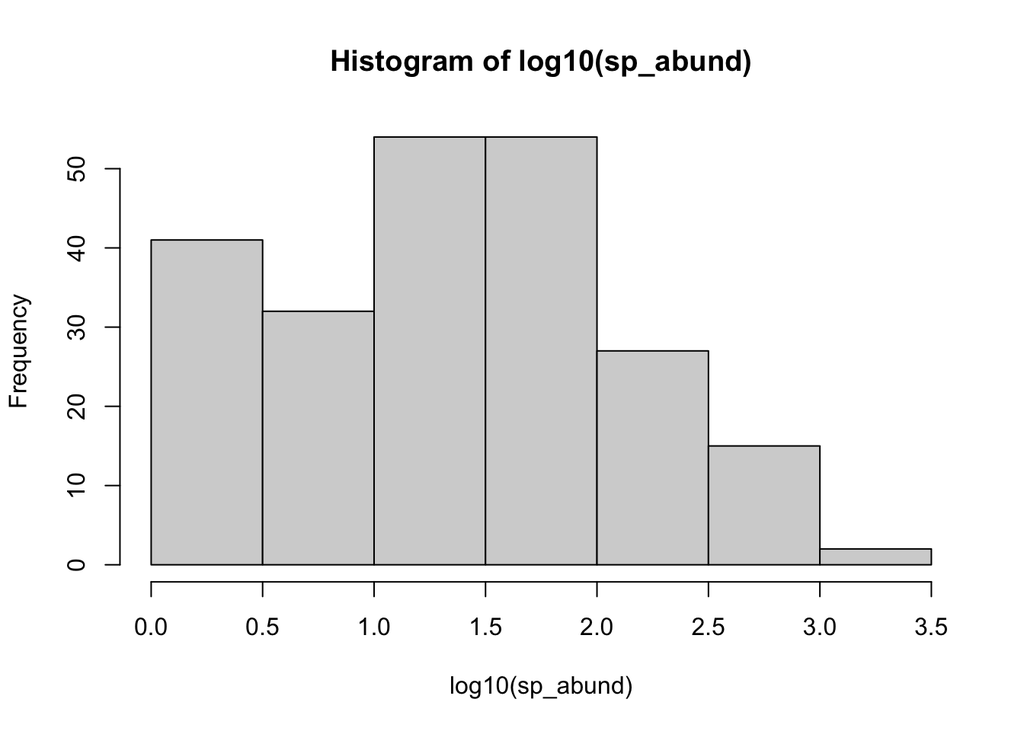

```r
hist(log10(sp_abund)) # log transformation for normal distribution
```

```r
quantile(sp_abund)
```

```
##   0%  25%  50%  75% 100%
##    1    7   25   82 1717
```

```r
quantile(log10(sp_abund))
```

```
##       0%      25%      50%      75%     100%
## 0.000000 0.845098 1.397940 1.913814 3.234770
```

```r
which(sp_abund >25 & sp_abund < 27)
```

```
## Erythrina.costaricensis          Inga.acuminata       Sterculia.apetala
##                      65                     100                     187
##   Symphonia.globulifera
##                     190
```

```r
which(sp_abund > 10^1.93 & sp_abund < 10^1.95)
```

```
## Cassipourea.guianensis   Dendropanax.arboreus
##                     32                     58
```

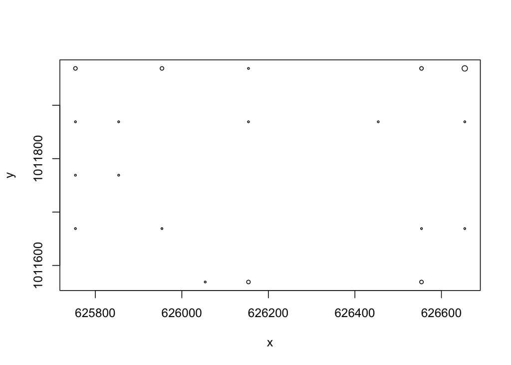

```r
rare <- BCI[ , 190]
common <- BCI[ , 32]

plot(BCI_xy, cex = rare/max(rare))
```

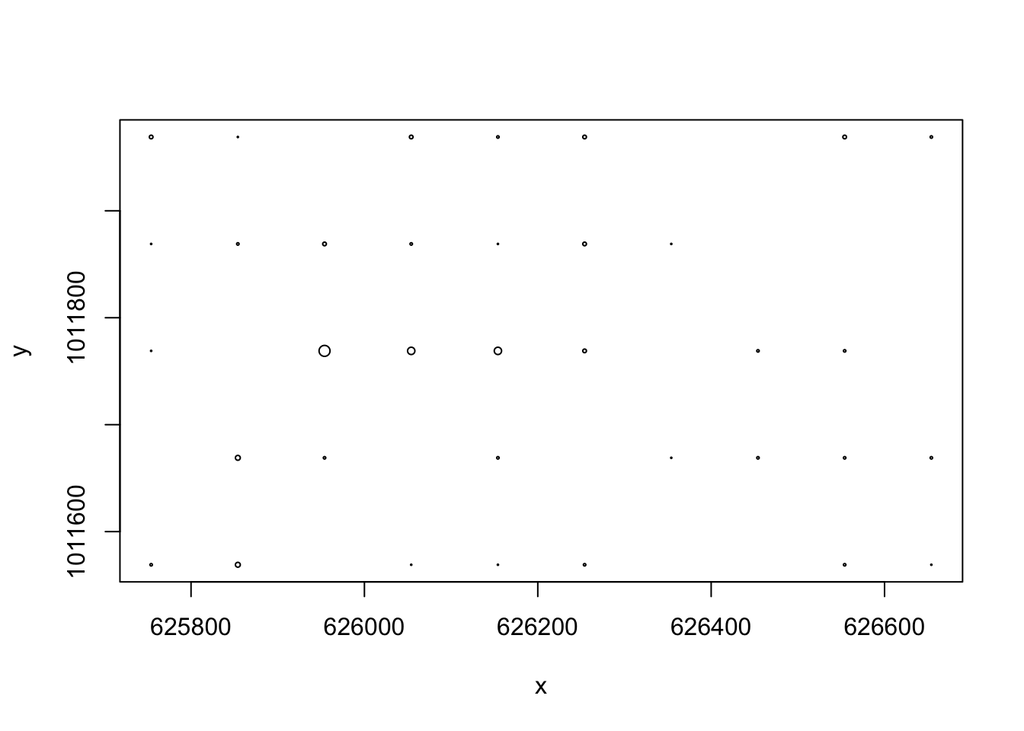

```r
plot(BCI_xy, cex = common/max(common))
```

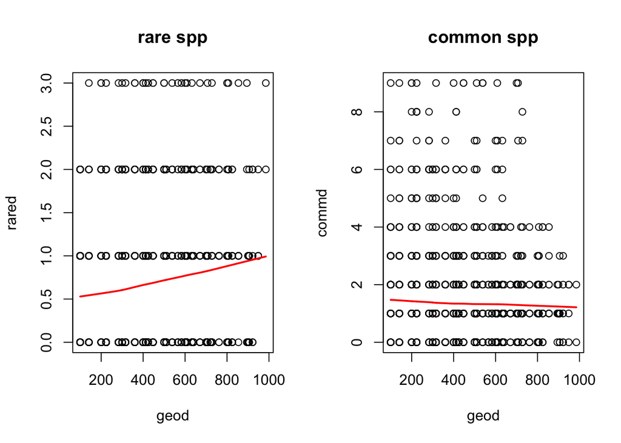

```r
geod <- dist(BCI_xy)
rared <- dist(rare)
commd <- dist(common)

maxdist <- max(geod)/2

par(mfrow=c(1,2))
plot(geod, rared, main = 'rare spp')
lines(lowess(geod, rared), lw=2, col='red')
plot(geod, commd, main = 'common spp')
lines(lowess(geod, commd), lw=2, col='red')
```

```r
# run mantel test and corellogram

rare_mantel <- mantel(rared, geod)
rare_mantel
```

```
##
## Mantel statistic based on Pearson's product-moment correlation
##
## Call:
## mantel(xdis = rared, ydis = geod)
##
## Mantel statistic r: 0.1418
##       Significance: 0.007
##
## Upper quantiles of permutations (null model):
##    90%    95%  97.5%    99%
## 0.0771 0.1038 0.1158 0.1308
## Permutation: free
## Number of permutations: 999
```

```r
common_mantel <- mantel(commd, geod)
common_mantel
```

```
##
## Mantel statistic based on Pearson's product-moment correlation
##
## Call:
## mantel(xdis = commd, ydis = geod)
##
## Mantel statistic r: -0.07249
##       Significance: 0.912
##
## Upper quantiles of permutations (null model):
##    90%    95%  97.5%    99%
## 0.0796 0.1023 0.1246 0.1453
## Permutation: free
## Number of permutations: 999
```

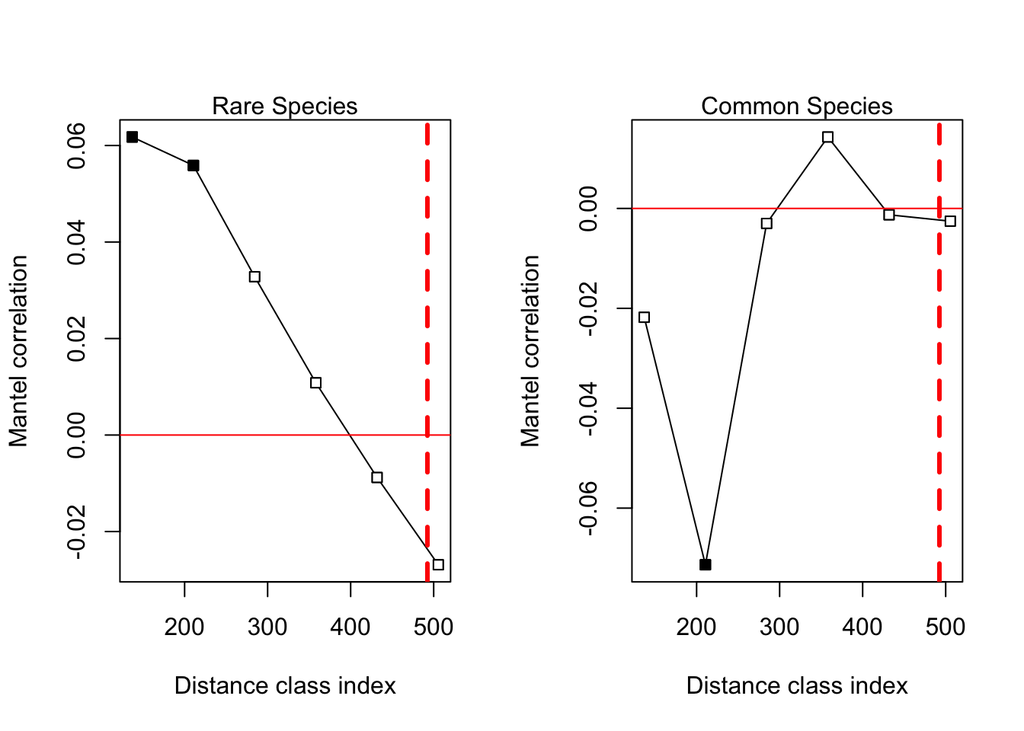

```r
rare_corlgrm <- mantel.correlog(rared, geod)

common_corlgrm <- mantel.correlog(commd, geod)


par(mfrow=c(1,2))
plot(rare_corlgrm)
mtext(side=3, 'Rare Species')
abline(v = maxdist, col='red', lwd=3, lty=2)
plot(common_corlgrm)
mtext(side=3, 'Common Species')
abline(v = maxdist, col='red', lwd=3, lty=2)
```

2. Build two generalized linear models to predict the abundance of the species *Drypetes standleyi* using the abundance of other tree species in the study site. Specifically examine the following species as predictor variables:

```r
sp_ids = c("Cordia.lasiocalyx", "Hirtella.triandra",
           "Picramnia.latifolia", "Quassia.amara",
           "Tabernaemontana.arborea", "Trattinnickia.aspera",
           "Xylopia.macrantha")
```

```r
library(nlme)

pred_sp <- BCI[ , sp_ids]

resp_sp <- BCI[ , 'Drypetes.standleyi']

sp_dat <- data.frame(pred_sp, resp_sp, BCI_xy)

pred_sp_log <- log10(pred_sp+1)

resp_sp_log <- log10(resp_sp+1)

sp_dat_log <- data.frame(pred_sp_log, resp_sp_log, BCI_xy)

sp_mod1 <- gls(resp_sp ~ Xylopia.macrantha, data=sp_dat)
summary(sp_mod1)
```

```
## Generalized least squares fit by REML
##   Model: resp_sp ~ Xylopia.macrantha
##   Data: sp_dat
##        AIC      BIC    logLik
##   338.2919 343.9055 -166.1459
##
## Coefficients:
##                      Value Std.Error  t-value p-value
## (Intercept)       3.285252 1.0990108 2.989281  0.0044
## Xylopia.macrantha 0.844318 0.1804326 4.679407  0.0000
##
##  Correlation:
##                   (Intr)
## Xylopia.macrantha -0.47
##
## Standardized residuals:
##        Min         Q1        Med         Q3        Max
## -1.3044324 -0.4788137 -0.3103771  0.1041720  3.9616489
##
## Residual standard error: 6.861233
## Degrees of freedom: 50 total; 48 residual
```

```r
sp_mod2 <- gls(resp_sp ~ . -(x+y), data=sp_dat)
summary(sp_mod2)
```

```
## Generalized least squares fit by REML
##   Model: resp_sp ~ . - (x + y)
##   Data: sp_dat
##        AIC      BIC    logLik
##   307.1163 322.7554 -144.5582
##
## Coefficients:
##                             Value Std.Error   t-value p-value
## (Intercept)             -1.051752 2.1175346 -0.496687  0.6220
## Cordia.lasiocalyx        0.428920 0.2039316  2.103255  0.0415
## Hirtella.triandra        0.122279 0.0802638  1.523462  0.1351
## Picramnia.latifolia      0.662259 0.6358905  1.041468  0.3036
## Quassia.amara            4.085661 2.2842770  1.788602  0.0809
## Tabernaemontana.arborea -0.249725 0.1491192 -1.674667  0.1014
## Trattinnickia.aspera     1.349323 0.7147412  1.887848  0.0660
## Xylopia.macrantha        0.548832 0.1468772  3.736672  0.0006
##
##  Correlation:
##                         (Intr) Crd.ls Hrtll. Pcrmn. Qss.mr Tbrnm. Trttn.
## Cordia.lasiocalyx       -0.618
## Hirtella.triandra       -0.212 -0.354
## Picramnia.latifolia      0.025 -0.019 -0.381
## Quassia.amara            0.163 -0.378  0.307 -0.302
## Tabernaemontana.arborea -0.708  0.245  0.163 -0.113  0.148
## Trattinnickia.aspera    -0.139  0.187 -0.311  0.308 -0.708 -0.144
## Xylopia.macrantha       -0.140 -0.125  0.156 -0.463  0.314  0.279 -0.294
##
## Standardized residuals:
##         Min          Q1         Med          Q3         Max
## -1.87708765 -0.42701500 -0.04032793  0.23615609  3.38768871
##
## Residual standard error: 4.539713
## Degrees of freedom: 50 total; 42 residual
```

```r
sp_mod2_log <- gls(resp_sp_log ~ . -(x+y), data=sp_dat_log)
summary(sp_mod2)
```

```
## Generalized least squares fit by REML
##   Model: resp_sp ~ . - (x + y)
##   Data: sp_dat
##        AIC      BIC    logLik
##   307.1163 322.7554 -144.5582
##
## Coefficients:
##                             Value Std.Error   t-value p-value
## (Intercept)             -1.051752 2.1175346 -0.496687  0.6220
## Cordia.lasiocalyx        0.428920 0.2039316  2.103255  0.0415
## Hirtella.triandra        0.122279 0.0802638  1.523462  0.1351
## Picramnia.latifolia      0.662259 0.6358905  1.041468  0.3036
## Quassia.amara            4.085661 2.2842770  1.788602  0.0809
## Tabernaemontana.arborea -0.249725 0.1491192 -1.674667  0.1014
## Trattinnickia.aspera     1.349323 0.7147412  1.887848  0.0660
## Xylopia.macrantha        0.548832 0.1468772  3.736672  0.0006
##
##  Correlation:
##                         (Intr) Crd.ls Hrtll. Pcrmn. Qss.mr Tbrnm. Trttn.
## Cordia.lasiocalyx       -0.618
## Hirtella.triandra       -0.212 -0.354
## Picramnia.latifolia      0.025 -0.019 -0.381
## Quassia.amara            0.163 -0.378  0.307 -0.302
## Tabernaemontana.arborea -0.708  0.245  0.163 -0.113  0.148
## Trattinnickia.aspera    -0.139  0.187 -0.311  0.308 -0.708 -0.144
## Xylopia.macrantha       -0.140 -0.125  0.156 -0.463  0.314  0.279 -0.294
##
## Standardized residuals:
##         Min          Q1         Med          Q3         Max
## -1.87708765 -0.42701500 -0.04032793  0.23615609  3.38768871
##
## Residual standard error: 4.539713
## Degrees of freedom: 50 total; 42 residual
```

Note renaming the species ids to something a little easier to work with like “sp_a”, “sp_b” will make model construction a little less cumbersome

- Model 1: only include a single species as a predictor variable
- Model 2: include all of the species as predictor variables

  Model 1, with only one species as a predictor, shows strong spatial correlation. The semivariogram first reaches 1.0 at a distance somewhere between 450 to 500, and there appears to be a nugget at about 0.3. However, Model 2, with all species included as predictors, does not appear to show spatial correlation. Using a different spatial correlation structure might yield different results for model 2. Of note, the semivariogram in model 2 does not appear to fit the data as well as in model 1. While the semivariogram in model 2 did not reach 1, there are data at or slightly above 1, beginning at distance of about 410, and based on visual inspection, there is a nugget at about 0.7.

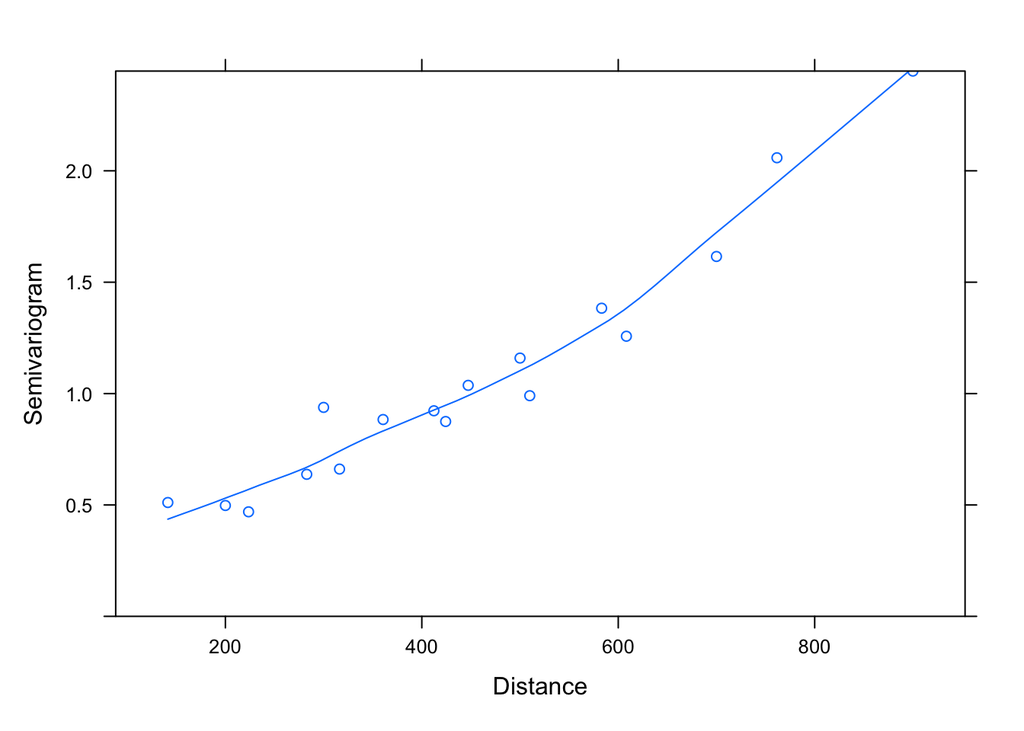

```r
plot(Variogram(sp_mod1, form = ~x+y))
```

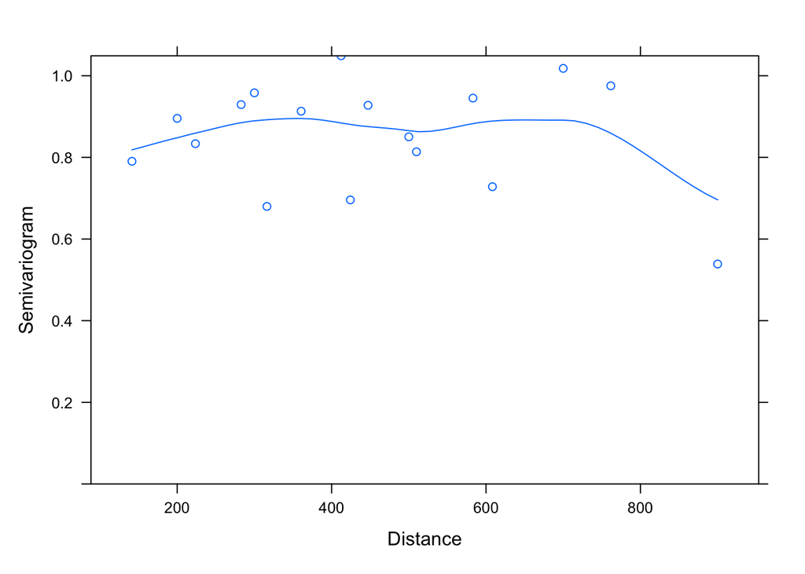

```r
plot(Variogram(sp_mod2, form = ~x+y))
```

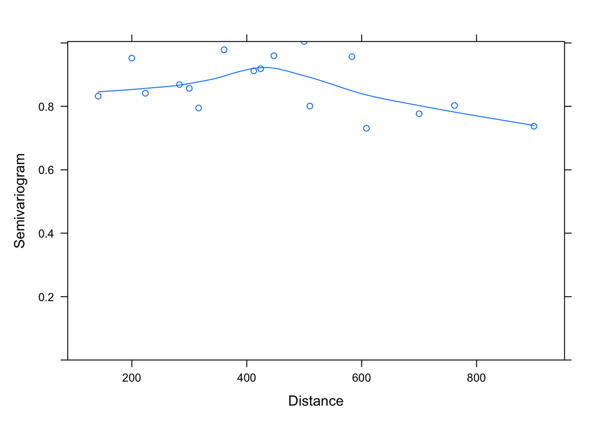

```r
plot(Variogram(sp_mod2_log, form = ~x+y))
```

With both models examine the spatial dependence of the residuals using the function `Variogram`. Model the spatial dependence in the residuals using one of the error structures available.

```r
sp_mod1_spher <- update(sp_mod1,
corr=corSpher(c(475,0.3), form = ~x+y, nugget=T))
summary(sp_mod1_spher)
```

```
## Generalized least squares fit by REML
##   Model: resp_sp ~ Xylopia.macrantha
##   Data: sp_dat
##        AIC      BIC    logLik
##   308.5425 317.8985 -149.2713
##
## Correlation Structure: Spherical spatial correlation
##  Formula: ~x + y
##  Parameter estimate(s):
##        range       nugget
## 2.437056e+06 5.516515e-05
##
## Coefficients:
##                       Value Std.Error   t-value p-value
## (Intercept)       11.294976  402.0031 0.0280967  0.9777
## Xylopia.macrantha  0.336005    0.1695 1.9824980  0.0532
##
##  Correlation:
##                   (Intr)
## Xylopia.macrantha -0.001
##
## Standardized residuals:
##         Min          Q1         Med          Q3         Max
## -0.03143361 -0.02809098 -0.02311692 -0.01192527  0.05219021
##
## Residual standard error: 402.0855
## Degrees of freedom: 50 total; 48 residual
```

```r
sp_mod1_exp <- update(sp_mod1,
corr=corExp(form = ~ x+y))
summary(sp_mod1_exp)
```

```
## Generalized least squares fit by REML
##   Model: resp_sp ~ Xylopia.macrantha
##   Data: sp_dat
##        AIC      BIC    logLik
##   308.6325 316.1173 -150.3163
##
## Correlation Structure: Exponential spatial correlation
##  Formula: ~x + y
##  Parameter estimate(s):
##      range
## 1583314148
##
## Coefficients:
##                       Value Std.Error   t-value p-value
## (Intercept)       13.820270 18030.014 0.0007665  0.9994
## Xylopia.macrantha  0.292271     0.171 1.7064091  0.0944
##
##  Correlation:
##                   (Intr)
## Xylopia.macrantha 0
##
## Standardized residuals:
##           Min            Q1           Med            Q3           Max
## -0.0008313555 -0.0007665145 -0.0006555884 -0.0004060046  0.0010723401
##
## Residual standard error: 18030.02
## Degrees of freedom: 50 total; 48 residual
```

```r
sp_mod1_exp_nug <- update(sp_mod1, corr=corExp(form = ~ x+y, nugget=0.3))
summary(sp_mod1_exp_nug)
```

```
## Generalized least squares fit by REML
##   Model: resp_sp ~ Xylopia.macrantha
##   Data: sp_dat
##        AIC      BIC    logLik
##   310.6325 319.9885 -150.3163
##
## Correlation Structure: Exponential spatial correlation
##  Formula: ~x + y
##  Parameter estimate(s):
##        range       nugget
## 1583314147.8          0.1
##
## Coefficients:
##                       Value Std.Error   t-value p-value
## (Intercept)       13.820270 18030.014 0.0007665  0.9994
## Xylopia.macrantha  0.292271     0.171 1.7064091  0.0944
##
##  Correlation:
##                   (Intr)
## Xylopia.macrantha 0
##
## Standardized residuals:
##           Min            Q1           Med            Q3           Max
## -0.0008313555 -0.0007665145 -0.0006555884 -0.0004060046  0.0010723401
##
## Residual standard error: 18030.02
## Degrees of freedom: 50 total; 48 residual
```

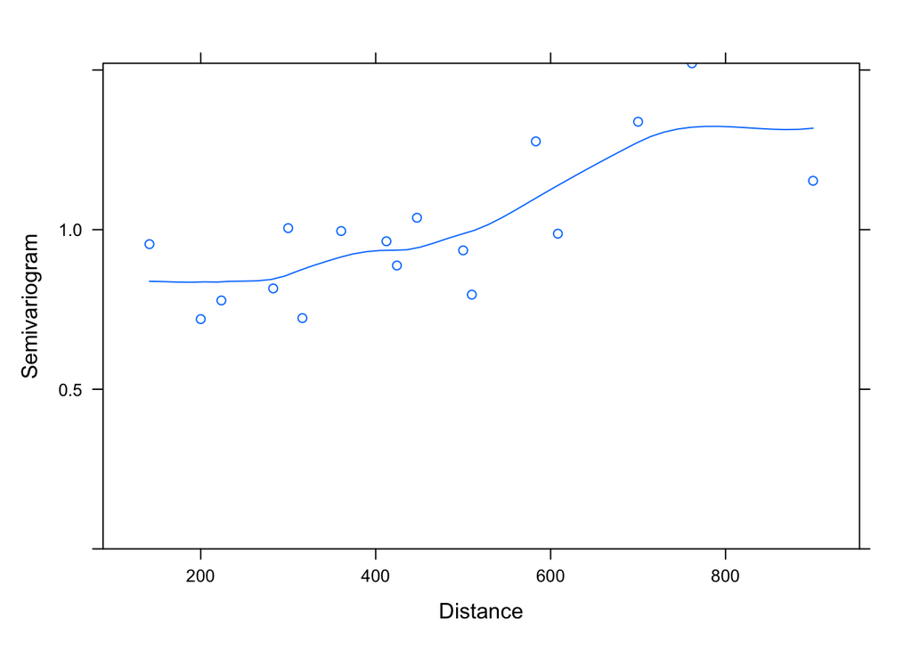

```r
plot(Variogram(sp_mod1_spher, resType = "n"))
```

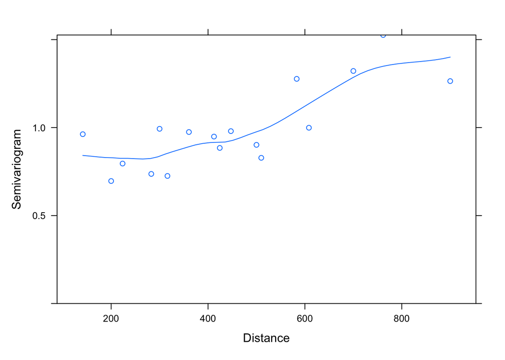

```r
plot(Variogram(sp_mod1_exp, resType = "n"))
```

```r
anova(sp_mod1, sp_mod1_spher, sp_mod1_exp, sp_mod1_exp_nug)
```

```
##                 Model df      AIC      BIC    logLik   Test  L.Ratio p-value
## sp_mod1             1  3 338.2919 343.9055 -166.1459
## sp_mod1_spher       2  5 308.5425 317.8985 -149.2713 1 vs 2 33.74932  <.0001
## sp_mod1_exp         3  4 308.6325 316.1173 -150.3163 2 vs 3  2.08999  0.1483
## sp_mod1_exp_nug     4  5 310.6325 319.9885 -150.3163 3 vs 4  0.00000  1.0000
```

```r
sp_mod2 <- gls(resp_sp ~ Cordia.lasiocalyx+Hirtella.triandra+Picramnia.latifolia+Quassia.amara+Tabernaemontana.arborea+Trattinnickia.aspera+Xylopia.macrantha, data = sp_dat)
summary(sp_mod2)
```

```
## Generalized least squares fit by REML
##   Model: resp_sp ~ Cordia.lasiocalyx + Hirtella.triandra + Picramnia.latifolia +      Quassia.amara + Tabernaemontana.arborea + Trattinnickia.aspera +      Xylopia.macrantha
##   Data: sp_dat
##        AIC      BIC    logLik
##   307.1163 322.7554 -144.5582
##
## Coefficients:
##                             Value Std.Error   t-value p-value
## (Intercept)             -1.051752 2.1175346 -0.496687  0.6220
## Cordia.lasiocalyx        0.428920 0.2039316  2.103255  0.0415
## Hirtella.triandra        0.122279 0.0802638  1.523462  0.1351
## Picramnia.latifolia      0.662259 0.6358905  1.041468  0.3036
## Quassia.amara            4.085661 2.2842770  1.788602  0.0809
## Tabernaemontana.arborea -0.249725 0.1491192 -1.674667  0.1014
## Trattinnickia.aspera     1.349323 0.7147412  1.887848  0.0660
## Xylopia.macrantha        0.548832 0.1468772  3.736672  0.0006
##
##  Correlation:
##                         (Intr) Crd.ls Hrtll. Pcrmn. Qss.mr Tbrnm. Trttn.
## Cordia.lasiocalyx       -0.618
## Hirtella.triandra       -0.212 -0.354
## Picramnia.latifolia      0.025 -0.019 -0.381
## Quassia.amara            0.163 -0.378  0.307 -0.302
## Tabernaemontana.arborea -0.708  0.245  0.163 -0.113  0.148
## Trattinnickia.aspera    -0.139  0.187 -0.311  0.308 -0.708 -0.144
## Xylopia.macrantha       -0.140 -0.125  0.156 -0.463  0.314  0.279 -0.294
##
## Standardized residuals:
##         Min          Q1         Med          Q3         Max
## -1.87708765 -0.42701500 -0.04032793  0.23615609  3.38768871
##
## Residual standard error: 4.539713
## Degrees of freedom: 50 total; 42 residual
```

```r
sp_mod2_spher <- update(sp_mod2, corr=corSpher(c(410, 0.7), form =~x+y, nugget=T))
summary(sp_mod2_spher)
```

```
## Generalized least squares fit by REML
##   Model: resp_sp ~ Cordia.lasiocalyx + Hirtella.triandra + Picramnia.latifolia +      Quassia.amara + Tabernaemontana.arborea + Trattinnickia.aspera +      Xylopia.macrantha
##   Data: sp_dat
##        AIC      BIC    logLik
##   301.9592 321.0735 -139.9796
##
## Correlation Structure: Spherical spatial correlation
##  Formula: ~x + y
##  Parameter estimate(s):
##        range       nugget
## 2.371502e+06 8.409440e-05
##
## Coefficients:
##                              Value Std.Error   t-value p-value
## (Intercept)              3.0501147 304.70420  0.010010  0.9921
## Cordia.lasiocalyx        0.1426669   0.18953  0.752753  0.4558
## Hirtella.triandra       -0.0017715   0.09038 -0.019601  0.9845
## Picramnia.latifolia      0.2863342   0.52743  0.542881  0.5901
## Quassia.amara            1.3263660   1.93681  0.684819  0.4972
## Tabernaemontana.arborea  0.0407527   0.13952  0.292083  0.7717
## Trattinnickia.aspera     1.8170750   0.57297  3.171301  0.0028
## Xylopia.macrantha        0.4086706   0.15367  2.659329  0.0110
##
##  Correlation:
##                         (Intr) Crd.ls Hrtll. Pcrmn. Qss.mr Tbrnm. Trttn.
## Cordia.lasiocalyx       -0.005
## Hirtella.triandra       -0.006 -0.098
## Picramnia.latifolia      0.001  0.017 -0.360
## Quassia.amara           -0.001 -0.292  0.344 -0.193
## Tabernaemontana.arborea -0.004 -0.020  0.160 -0.197  0.088
## Trattinnickia.aspera    -0.002  0.165 -0.276  0.255 -0.655 -0.036
## Xylopia.macrantha       -0.001 -0.066 -0.037 -0.048  0.306  0.140 -0.183
##
## Standardized residuals:
##          Min           Q1          Med           Q3          Max
## -0.028891815 -0.017037979 -0.012108230  0.003262513  0.060739206
##
## Residual standard error: 304.7554
## Degrees of freedom: 50 total; 42 residual
```

```r
sp_mod2_exp <- update(sp_mod2, corr=corExp(form =~x+y, nugget=T))
summary(sp_mod2_exp)
```

```
## Generalized least squares fit by REML
##   Model: resp_sp ~ Cordia.lasiocalyx + Hirtella.triandra + Picramnia.latifolia +      Quassia.amara + Tabernaemontana.arborea + Trattinnickia.aspera +      Xylopia.macrantha
##   Data: sp_dat
##        AIC      BIC    logLik
##   301.9592 321.0735 -139.9796
##
## Correlation Structure: Exponential spatial correlation
##  Formula: ~x + y
##  Parameter estimate(s):
##        range       nugget
## 5.424635e+07 2.451077e-06
##
## Coefficients:
##                              Value Std.Error   t-value p-value
## (Intercept)              3.0501045 1785.0597  0.001709  0.9986
## Cordia.lasiocalyx        0.1426666    0.1895  0.752752  0.4558
## Hirtella.triandra       -0.0017714    0.0904 -0.019600  0.9845
## Picramnia.latifolia      0.2863335    0.5274  0.542880  0.5901
## Quassia.amara            1.3263643    1.9368  0.684818  0.4972
## Tabernaemontana.arborea  0.0407530    0.1395  0.292085  0.7717
## Trattinnickia.aspera     1.8170749    0.5730  3.171303  0.0028
## Xylopia.macrantha        0.4086700    0.1537  2.659324  0.0110
##
##  Correlation:
##                         (Intr) Crd.ls Hrtll. Pcrmn. Qss.mr Tbrnm. Trttn.
## Cordia.lasiocalyx       -0.001
## Hirtella.triandra       -0.001 -0.098
## Picramnia.latifolia      0.000  0.017 -0.360
## Quassia.amara            0.000 -0.292  0.344 -0.193
## Tabernaemontana.arborea -0.001 -0.020  0.160 -0.197  0.088
## Trattinnickia.aspera     0.000  0.165 -0.276  0.255 -0.655 -0.036
## Xylopia.macrantha        0.000 -0.066 -0.037 -0.048  0.306  0.140 -0.183
##
## Standardized residuals:
##           Min            Q1           Med            Q3           Max
## -0.0049325435 -0.0029088009 -0.0020671675  0.0005570041  0.0103697005
##
## Residual standard error: 1785.068
## Degrees of freedom: 50 total; 42 residual
```

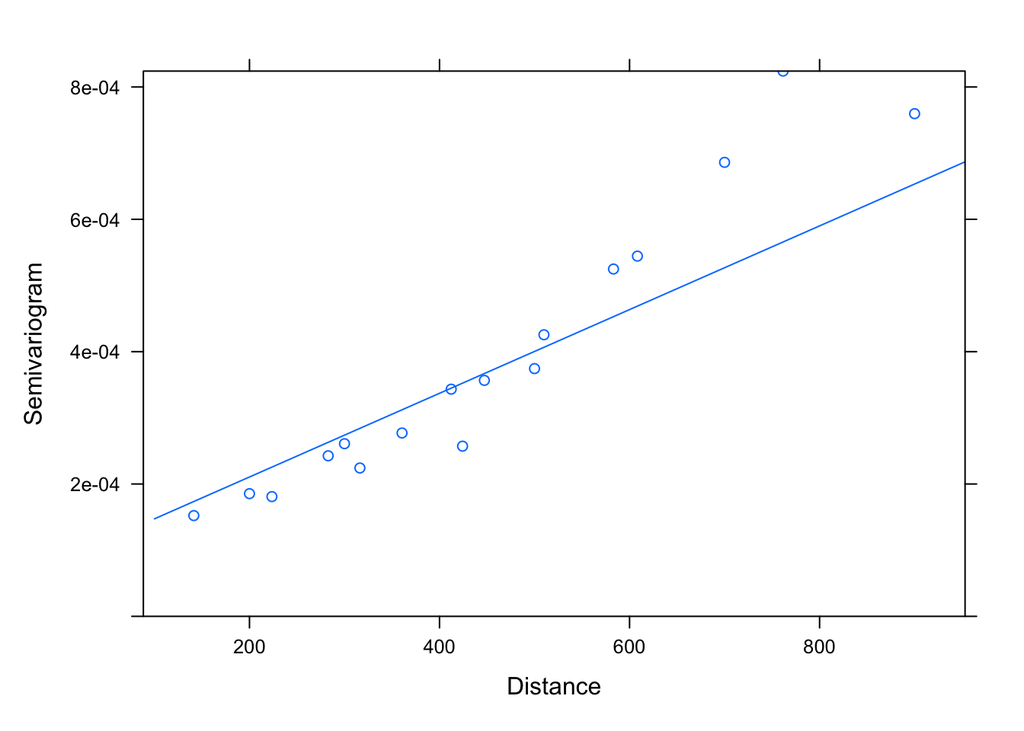

```r
plot(Variogram(sp_mod2_spher, form = ~x+y))
```

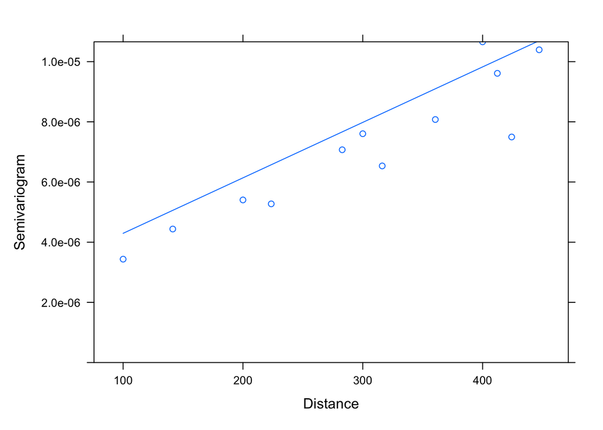

```r
plot(Variogram(sp_mod2_exp, form = ~x+y, maxDist=maxdist))
```

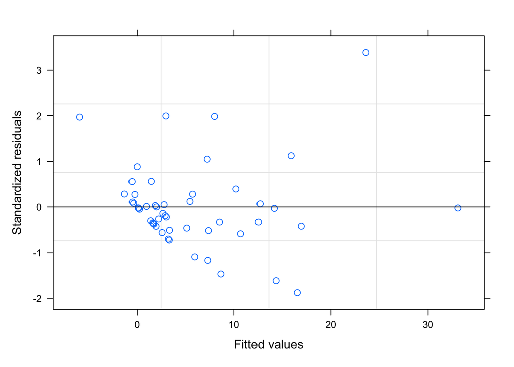

```r
plot(sp_mod2,resid( ., type="n")~fitted(.),abline=0)
```

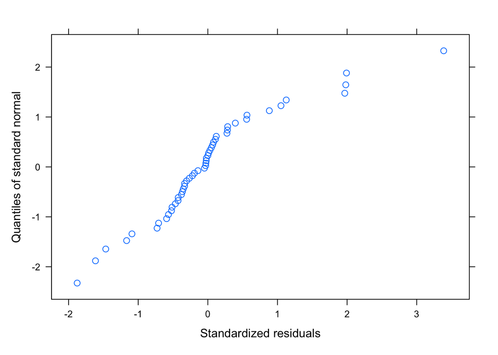

```r
qqnorm(sp_mod2,~resid(.,type="n"))
```

```r
sp_mod2_log <- gls(resp_sp_log ~ Cordia.lasiocalyx+Hirtella.triandra+Picramnia.latifolia+Quassia.amara+Tabernaemontana.arborea+Trattinnickia.aspera+Xylopia.macrantha, data = sp_dat_log)
summary(sp_mod2_log)
```

```
## Generalized least squares fit by REML
##   Model: resp_sp_log ~ Cordia.lasiocalyx + Hirtella.triandra + Picramnia.latifolia +      Quassia.amara + Tabernaemontana.arborea + Trattinnickia.aspera +      Xylopia.macrantha
##   Data: sp_dat_log
##        AIC     BIC    logLik
##   42.64357 58.2826 -12.32179
##
## Coefficients:
##                              Value Std.Error   t-value p-value
## (Intercept)              0.4560385 0.2619458  1.740965  0.0890
## Cordia.lasiocalyx        0.1771392 0.2003746  0.884040  0.3817
## Hirtella.triandra        0.2047783 0.1576653  1.298816  0.2011
## Picramnia.latifolia      0.5341870 0.2156698  2.476874  0.0174
## Quassia.amara            0.4346630 0.5518608  0.787632  0.4353
## Tabernaemontana.arborea -0.6190140 0.1539249 -4.021532  0.0002
## Trattinnickia.aspera     0.1382120 0.2164133  0.638649  0.5265
## Xylopia.macrantha        0.2200386 0.1203122  1.828897  0.0745
##
##  Correlation:
##                         (Intr) Crd.ls Hrtll. Pcrmn. Qss.mr Tbrnm. Trttn.
## Cordia.lasiocalyx       -0.588
## Hirtella.triandra       -0.430 -0.284
## Picramnia.latifolia      0.126 -0.079 -0.269
## Quassia.amara           -0.054 -0.195  0.198 -0.303
## Tabernaemontana.arborea -0.728  0.307  0.118 -0.102  0.254
## Trattinnickia.aspera     0.049  0.125 -0.281  0.313 -0.536 -0.211
## Xylopia.macrantha       -0.105 -0.129  0.016 -0.399  0.222  0.273 -0.251
##
## Standardized residuals:
##         Min          Q1         Med          Q3         Max
## -1.71650772 -0.64814575 -0.07390826  0.47131456  2.96711269
##
## Residual standard error: 0.2877245
## Degrees of freedom: 50 total; 42 residual
```

```r
sp_mod2_spher_log <- update(sp_mod2_log, corr=corSpher(c(410, 0.7), form =~x+y, nugget=T))
summary(sp_mod2_spher_log)
```

```
## Generalized least squares fit by REML
##   Model: resp_sp_log ~ Cordia.lasiocalyx + Hirtella.triandra + Picramnia.latifolia +      Quassia.amara + Tabernaemontana.arborea + Trattinnickia.aspera +      Xylopia.macrantha
##   Data: sp_dat_log
##        AIC     BIC    logLik
##   34.32873 53.4431 -6.164366
##
## Correlation Structure: Spherical spatial correlation
##  Formula: ~x + y
##  Parameter estimate(s):
##        range       nugget
## 1.497504e+06 1.772806e-04
##
## Coefficients:
##                              Value Std.Error    t-value p-value
## (Intercept)              0.6893377 13.598163  0.0506934  0.9598
## Cordia.lasiocalyx       -0.0585536  0.172415 -0.3396092  0.7358
## Hirtella.triandra        0.0674963  0.153683  0.4391927  0.6628
## Picramnia.latifolia      0.2656187  0.179665  1.4784087  0.1468
## Quassia.amara            0.1702101  0.456593  0.3727829  0.7112
## Tabernaemontana.arborea -0.1842291  0.153560 -1.1997226  0.2370
## Trattinnickia.aspera     0.1969408  0.169357  1.1628737  0.2514
## Xylopia.macrantha        0.1416835  0.124322  1.1396454  0.2609
##
##  Correlation:
##                         (Intr) Crd.ls Hrtll. Pcrmn. Qss.mr Tbrnm. Trttn.
## Cordia.lasiocalyx       -0.012
## Hirtella.triandra       -0.013 -0.157
## Picramnia.latifolia      0.003 -0.067 -0.195
## Quassia.amara           -0.003 -0.195  0.235 -0.228
## Tabernaemontana.arborea -0.012  0.118  0.127 -0.306  0.175
## Trattinnickia.aspera    -0.003  0.192 -0.210  0.257 -0.488 -0.111
## Xylopia.macrantha       -0.001 -0.097 -0.096 -0.158  0.278  0.150 -0.190
##
## Standardized residuals:
##          Min           Q1          Med           Q3          Max
## -0.053793770 -0.036318332 -0.009759369  0.012174042  0.035520594
##
## Residual standard error: 13.59993
## Degrees of freedom: 50 total; 42 residual
```

```r
sp_mod2_exp_log <- update(sp_mod2_log, corr=corExp(form =~x+y))
summary(sp_mod2_exp_log)
```

```
## Generalized least squares fit by REML
##   Model: resp_sp_log ~ Cordia.lasiocalyx + Hirtella.triandra + Picramnia.latifolia +      Quassia.amara + Tabernaemontana.arborea + Trattinnickia.aspera +      Xylopia.macrantha
##   Data: sp_dat_log
##        AIC      BIC    logLik
##   34.04153 51.41822 -7.020764
##
## Correlation Structure: Exponential spatial correlation
##  Formula: ~x + y
##  Parameter estimate(s):
##    range
## 364.4322
##
## Coefficients:
##                              Value Std.Error    t-value p-value
## (Intercept)              0.6437197 0.3950961  1.6292737  0.1107
## Cordia.lasiocalyx       -0.0827804 0.1662018 -0.4980715  0.6210
## Hirtella.triandra        0.0664522 0.1694687  0.3921210  0.6970
## Picramnia.latifolia      0.2647215 0.1739170  1.5221143  0.1355
## Quassia.amara            0.1652636 0.4399847  0.3756121  0.7091
## Tabernaemontana.arborea -0.1674980 0.1468135 -1.1408894  0.2604
## Trattinnickia.aspera     0.2146633 0.1574360  1.3634957  0.1800
## Xylopia.macrantha        0.1180631 0.1246118  0.9474475  0.3488
##
##  Correlation:
##                         (Intr) Crd.ls Hrtll. Pcrmn. Qss.mr Tbrnm. Trttn.
## Cordia.lasiocalyx       -0.381
## Hirtella.triandra       -0.503 -0.089
## Picramnia.latifolia      0.160 -0.149 -0.208
## Quassia.amara           -0.104 -0.207  0.216 -0.216
## Tabernaemontana.arborea -0.462  0.142  0.251 -0.355  0.203
## Trattinnickia.aspera    -0.074  0.228 -0.171  0.218 -0.483 -0.112
## Xylopia.macrantha        0.010 -0.145 -0.146 -0.050  0.267  0.082 -0.208
##
## Standardized residuals:
##        Min         Q1        Med         Q3        Max
## -1.4939543 -0.9542194 -0.1709455  0.4873636  1.2256562
##
## Residual standard error: 0.464747
## Degrees of freedom: 50 total; 42 residual
```

```r
sp_mod2_rat_log <- update(sp_mod2_log, corr=corRatio(form = ~x+y))
summary(sp_mod2_rat_log)
```

```
## Generalized least squares fit by REML
##   Model: resp_sp_log ~ Cordia.lasiocalyx + Hirtella.triandra + Picramnia.latifolia +      Quassia.amara + Tabernaemontana.arborea + Trattinnickia.aspera +      Xylopia.macrantha
##   Data: sp_dat_log
##        AIC     BIC    logLik
##   35.45491 52.8316 -7.727453
##
## Correlation Structure: Rational quadratic spatial correlation
##  Formula: ~x + y
##  Parameter estimate(s):
##    range
## 113.0278
##
## Coefficients:
##                              Value Std.Error    t-value p-value
## (Intercept)              0.5119956 0.3110014  1.6462804  0.1072
## Cordia.lasiocalyx       -0.0478848 0.1643635 -0.2913349  0.7722
## Hirtella.triandra        0.1297412 0.1781767  0.7281601  0.4706
## Picramnia.latifolia      0.3383932 0.1776951  1.9043477  0.0637
## Quassia.amara            0.2046866 0.4435881  0.4614339  0.6469
## Tabernaemontana.arborea -0.2191878 0.1402420 -1.5629253  0.1256
## Trattinnickia.aspera     0.2304194 0.1591841  1.4475021  0.1552
## Xylopia.macrantha        0.1268019 0.1194269  1.0617535  0.2944
##
##  Correlation:
##                         (Intr) Crd.ls Hrtll. Pcrmn. Qss.mr Tbrnm. Trttn.
## Cordia.lasiocalyx       -0.453
## Hirtella.triandra       -0.650 -0.085
## Picramnia.latifolia      0.233 -0.187 -0.216
## Quassia.amara           -0.084 -0.231  0.192 -0.216
## Tabernaemontana.arborea -0.594  0.185  0.302 -0.389  0.211
## Trattinnickia.aspera    -0.055  0.248 -0.170  0.191 -0.501 -0.129
## Xylopia.macrantha        0.039 -0.198 -0.128 -0.072  0.249  0.097 -0.271
##
## Standardized residuals:
##        Min         Q1        Med         Q3        Max
## -1.8108039 -0.9620116 -0.0481882  0.7109784  1.6528065
##
## Residual standard error: 0.3525504
## Degrees of freedom: 50 total; 42 residual
```

```r
sp_mod2_rat_log_nug <- update(sp_mod2_log, corr=corRatio(form = ~x+y, nugget=T))
summary(sp_mod2_rat_log_nug)
```

```
## Generalized least squares fit by REML
##   Model: resp_sp_log ~ Cordia.lasiocalyx + Hirtella.triandra + Picramnia.latifolia +      Quassia.amara + Tabernaemontana.arborea + Trattinnickia.aspera +      Xylopia.macrantha
##   Data: sp_dat_log
##        AIC      BIC    logLik
##   32.73592 51.85029 -5.367961
##
## Correlation Structure: Rational quadratic spatial correlation
##  Formula: ~x + y
##  Parameter estimate(s):
##        range       nugget
## 3.240868e+03 1.145075e-02
##
## Coefficients:
##                              Value Std.Error    t-value p-value
## (Intercept)              1.1724683 2.0308497  0.5773290  0.5668
## Cordia.lasiocalyx       -0.0008048 0.1670888 -0.0048167  0.9962
## Hirtella.triandra        0.0453871 0.1298090  0.3496449  0.7284
## Picramnia.latifolia      0.2791941 0.1772974  1.5747215  0.1228
## Quassia.amara            0.0250173 0.4499144  0.0556046  0.9559
## Tabernaemontana.arborea -0.2050475 0.1483406 -1.3822751  0.1742
## Trattinnickia.aspera     0.2126435 0.1748435  1.2161933  0.2307
## Xylopia.macrantha        0.1476610 0.1101938  1.3400115  0.1874
##
##  Correlation:
##                         (Intr) Crd.ls Hrtll. Pcrmn. Qss.mr Tbrnm. Trttn.
## Cordia.lasiocalyx       -0.140
## Hirtella.triandra       -0.110 -0.183
## Picramnia.latifolia     -0.006 -0.027 -0.171
## Quassia.amara           -0.020 -0.139  0.218 -0.227
## Tabernaemontana.arborea -0.046  0.157 -0.048 -0.250  0.115
## Trattinnickia.aspera    -0.063  0.154 -0.256  0.258 -0.512 -0.097
## Xylopia.macrantha        0.037 -0.082 -0.022 -0.311  0.282  0.183 -0.231
##
## Standardized residuals:
##         Min          Q1         Med          Q3         Max
## -0.57592784 -0.46898717 -0.29811500 -0.15514219 -0.01571562
##
## Residual standard error: 2.109988
## Degrees of freedom: 50 total; 42 residual
```

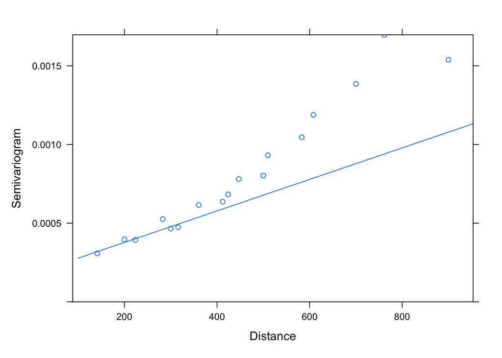

```r
plot(Variogram(sp_mod2_spher_log, form = ~x+y))
```

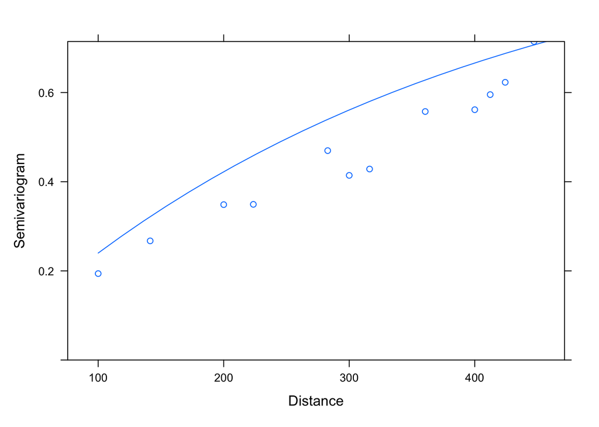

```r
plot(Variogram(sp_mod2_exp_log, form = ~x+y, maxDist=maxdist))
```

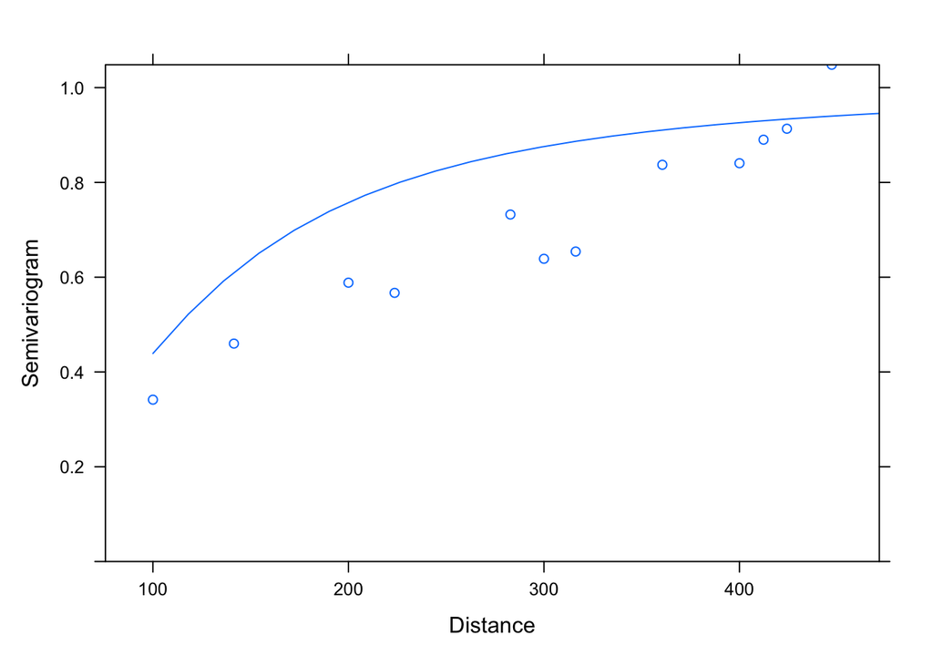

```r
plot(Variogram(sp_mod2_rat_log, maxDist = maxdist))
```

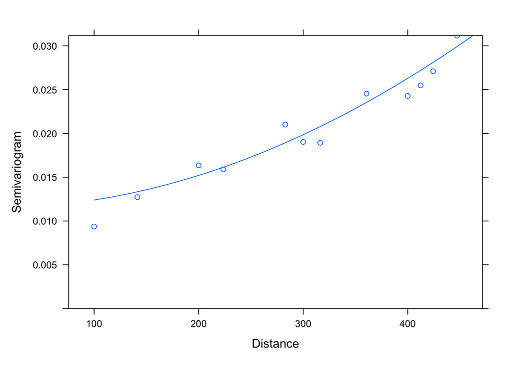

```r
plot(Variogram(sp_mod2_rat_log_nug, maxDist = maxdist))
```

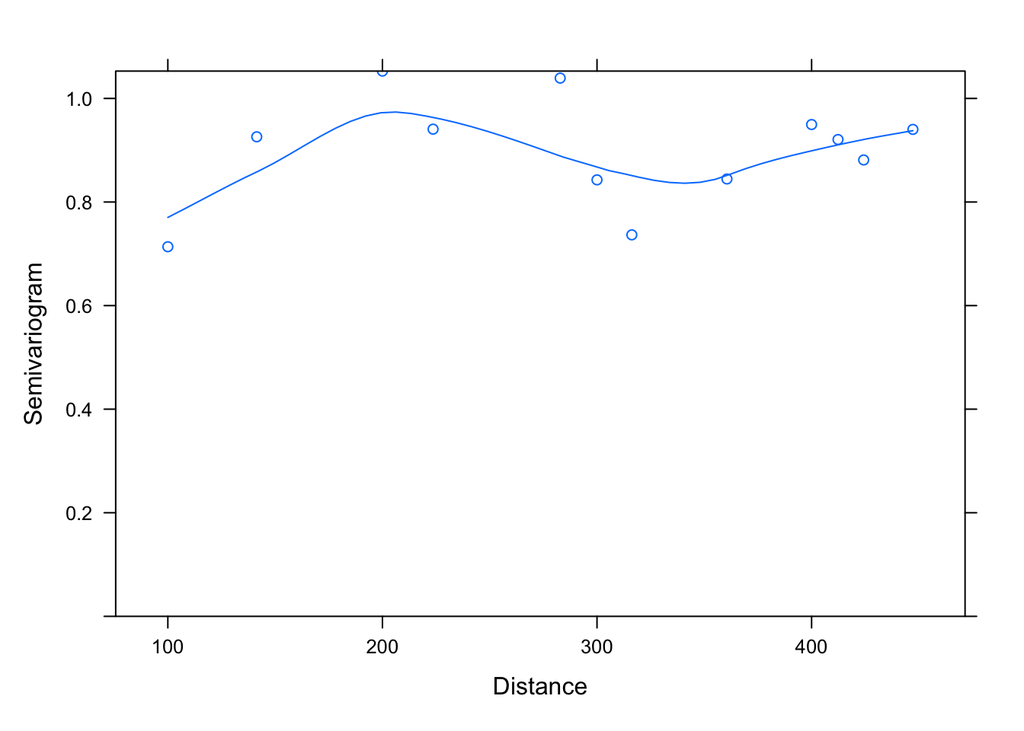

```r
plot(Variogram(sp_mod2_rat_log_nug, resType="n", maxDist = maxdist))
```

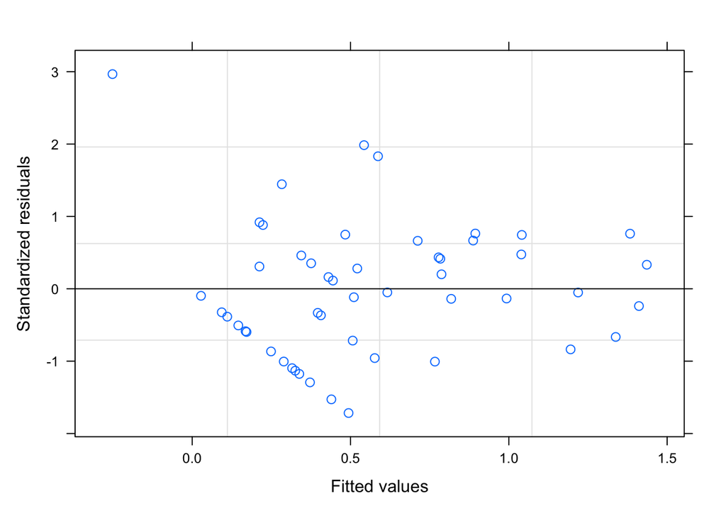

```r
plot(sp_mod2_log,resid( ., type="n")~fitted(.),abline=0)
```

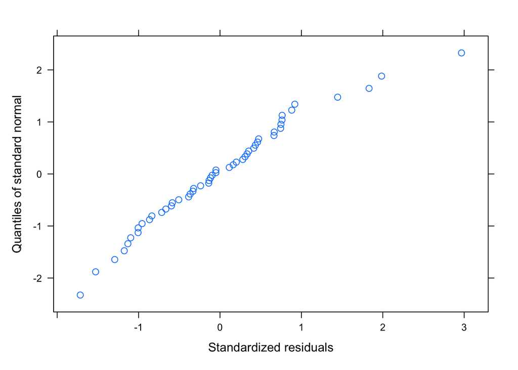

```r
qqnorm(sp_mod2_log,~resid(.,type="n"))
```

```r
anova(sp_mod2_log, sp_mod2_exp_log, sp_mod2_spher_log, sp_mod2_rat_log, sp_mod2_rat_log_nug)
```

```
##                     Model df      AIC      BIC     logLik   Test   L.Ratio
## sp_mod2_log             1  9 42.64357 58.28260 -12.321787
## sp_mod2_exp_log         2 10 34.04153 51.41822  -7.020764 1 vs 2 10.602046
## sp_mod2_spher_log       3 11 34.32873 53.44310  -6.164366 2 vs 3  1.712796
## sp_mod2_rat_log         4 10 35.45491 52.83160  -7.727453 3 vs 4  3.126174
## sp_mod2_rat_log_nug     5 11 32.73592 51.85029  -5.367961 4 vs 5  4.718984
##                     p-value
## sp_mod2_log
## sp_mod2_exp_log      0.0011
## sp_mod2_spher_log    0.1906
## sp_mod2_rat_log      0.0770
## sp_mod2_rat_log_nug  0.0298
```

- Did including the spatial error term have a large impact on the coefficients of the model?

  Model 1 appeared to be very spatially dependent, while model 2 did not. Using spherical or exponential spatial structuring provided significant improvement to model 1 compared to one with no spatial structuring, though neither spherical or exponential structuring was signifcantly better than the other.

  Model 2 did not appear to be spatially dependent based on visual inspection. I played around with some spatial structures, and while there was statistically significant improvement with spherical or exponential structuring compared to the model with no spatial structure, the improvement was less than that of Model 1, and the results of both spherical and exponential structuring were identical in Model 2. When I mapped out the residuals in model 2, it turned out that they were not normally distributed, which prompted me to log transform the data. This greatly improved the model, though did not change my visual interpretation of spatial dependence within the model. Under the log-transformed model, the original variogram still showed little visual evidence of spatial dependence, though there was statistical evidence that including spatial structuring in the model significantly improved the model. I tried 4 different models; rational, exponential, spherical, and rational with nugget. The best model was one with rational spatial structure with the nugget included.
- Explain why you did or did not observe a difference in the influence of adding the spatial error term between the two models.

  There was a difference in the influence of adding the spatial error term between the two models. The most likely reason for this is that the species included as predictors have different biology and might each be influenced by different kinds of spatial structuring. For example, it is possible that no single species included lacks spatial dependence. However, the kind of spatial dependence that each one is influenced by might be different. Species that are predators are more likely to be spatially structured by internal factors such as competition, while other species may be structured strongly by environmental factors. Thus, some species could be influenced strongly by induced spatial dependence, while others are autocorrelated. Therefore, our model examining one species as a predictor variable may be more strongly influenced by spatial structuring because it is more likely that only one kind spatial influence is present, which makes it easier to detect, and therefore easier to correct against. In the model with many species, different kinds of spatial influences may be causing an effect, and on top of that, each species included may have a different influence on the likelihood of our response species being present.